# homework_7

b06208016楊鎧綾

2018年10月26日

## 9.42

### a

1.know the population happened probability is 0.05  
2.data collection is random and repeat many times  
3.np and n(1-p) must be at least 10,this is 20 and 380

### b

```r
n=400
p=0.05
```

**n=400 and p =0.05**

### c

```r
mean=p;mean
```

```
## [1] 0.05
```

```r
sd=sqrt(p*(1-p)/n);sd
```

```
## [1] 0.01089725
```

**mean of phat is 0.05;sd of phat is 0.01089725**

### d

```r
28/400
```

```
## [1] 0.07
```

```r
1-pnorm(28/400,mean,sd)
```

```
## [1] 0.03322871
```

**the proportion is 0.07;0.033 exceed it**

## sampling distribution

```r
#sampling one time(function is for making one mean)
#機率為p的時候抽n個，回傳成功的機率
bino.x=function(n,p){
  pp=p*100
  samp=sample(1:100,n,replace=T)#隨機抽n個
  response=c()
  #確認哪些符合條件
  for (i in 1:length(samp)){
    if (samp[i]<=pp){
      response[i]=1
    }else{
      response[i]=0
    }
  }
  p=sum(response)/n
  return(p)#回傳符合的比例
}

#sampling multiple times
#return 1000 phat
simu.phat=c()
for (j in 1:1000){
  x=bino.x(400,0.05)
  simu.phat[j]=x
}
```

```r
#計算模擬的phat的mean和sd
simu.mean=mean(simu.phat)
simu.sd=sd(simu.phat)
#計算理論的phat的mean和sd
n=400
p=0.05
theo.mean=p
theo.sd=sqrt(p*(1-p)/n)
```

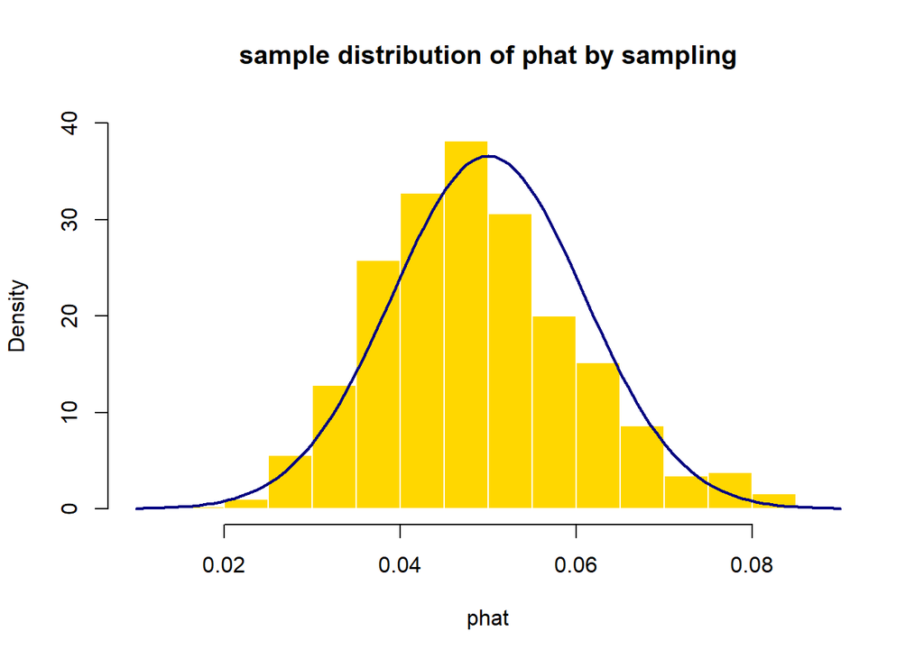

```r
#draw sample distribution
hist(simu.phat,probability = T,breaks = 20,main="sample distribution of phat by sampling",xlab="phat",col = "gold",border="white",ylim=c(0,40))
#加上理論的部分
curve(dnorm(x,theo.mean,theo.sd),add=T,col="navy",lwd=2)
```

## 9.54

### a

```r
p1=0.51
mean1=p1;mean1
```

```
## [1] 0.51
```

```r
sd1=sqrt(p1*(1-p1)/500);sd1
```

```
## [1] 0.02235621
```

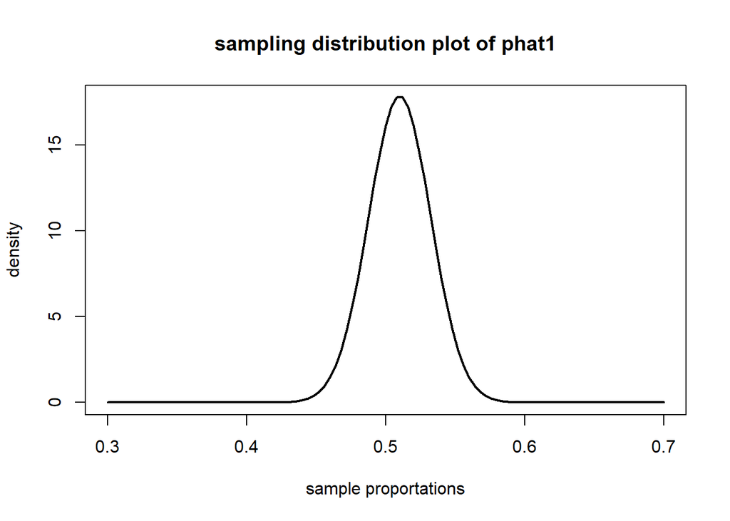

```r
curve(dnorm(x,mean1,sd1),lwd=2,xlim=c(0.3,0.7),main="sampling distribution plot of phat1",xlab="sample proportations",ylab="density")
```

**sampling distribution of phat1:mean=0.51;sd=0.02235621**

## b

```r
p2=0.48
mean2=p2
sd2=sqrt(p2*(1-p2)/500)
mean=mean1-mean2;mean
```

```
## [1] 0.03
```

**the mean is 0.03**

## C

```r
sd=sqrt((sd1)^2+(sd2)^2);sd
```

```
## [1] 0.03160696
```

**the sd is 0.03160696**

## d

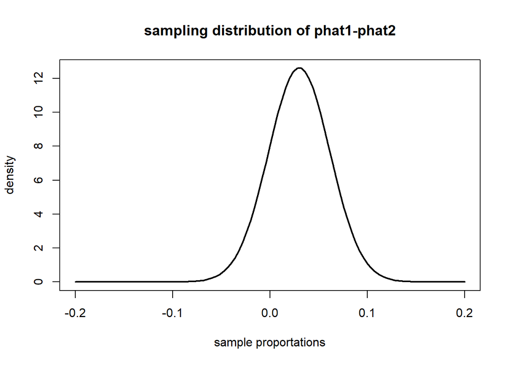

```r
curve(dnorm(x,mean,sd),lwd=2,main="sampling distribution of phat1-phat2",xlim=c(-0.2,0.2),xlab="sample proportations",ylab="density")
```

## e

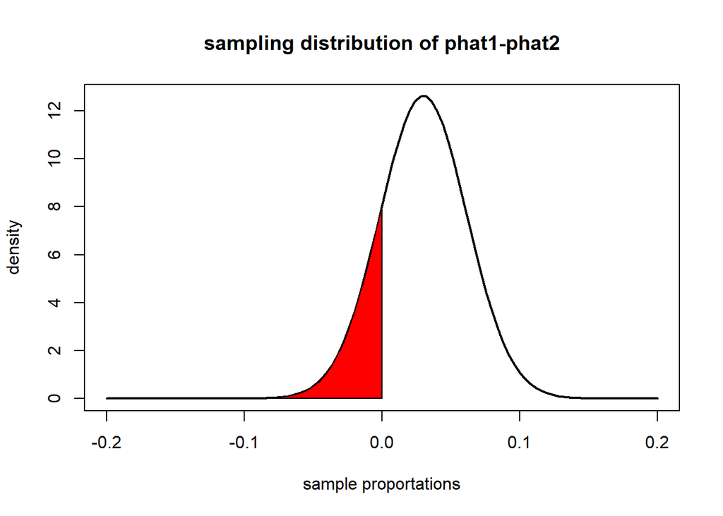

```r
x=seq(-0.2,0.2,length.out=1000)
y=dnorm(x,mean,sd)
curve(dnorm(x,mean,sd),lwd=2,main="sampling distribution of phat1-phat2",xlim=c(-0.2,0.2),xlab="sample proportations",ylab="density")
## Add the polygon
region.x = x[x<=0]
region.y = y[x<=0]
region.x2 = c(region.x,0)
region.y2 = c(region.y, 0)
polygon(region.x2, region.y2, col = "red")
```

**answer is the polygon of red color**

## f

```r
z=(0-mean)/sd
z
```

```
## [1] -0.949158
```

## 9.68

### a

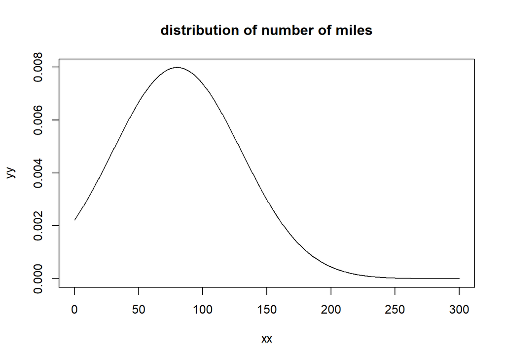

```r
xx = seq(0, 300, length.out = 1000)
yy = dnorm(xx, mean = 80, sd = 50)
plot(x = xx, y = yy, type = "l", main = "distribution of number of miles")
```

```r
xsam<-rnorm(1000,80,50)
xsam=xsam[xsam>0]
mean(xsam)>median(xsam)
```

```
## [1] TRUE
```

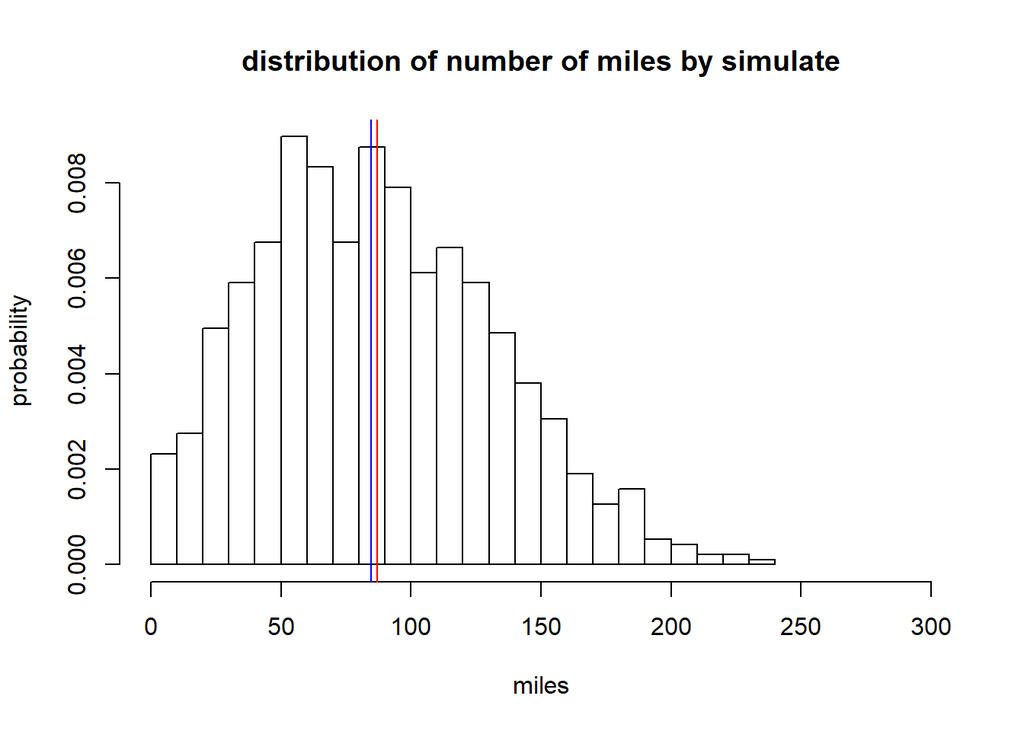

```r
hist(xsam,breaks=20,xlim=c(0,300),main="distribution of number of miles by simulate",xlab="miles",ylab="probability",prob=T)
abline(v = mean(xsam), col = "red")
abline(v = median(xsam), col = "blue")
```

**因為miles一定大於0，因此小於0的部分不能看，而根據上圖可發現右邊拉比較長，且mean>median，因此是skewed-right，不是normal distribution**

### b

```r
#sample one time
#每次有n個觀測者
norm.x=function(n,mu,sigma){
  samp=rnorm(n,mu,sigma)
  xbar=mean(samp)
  return(xbar)
}
#sample multiple times
simu.xbar=c()
for (j in 1:1000){
  x=norm.x(365,80,50)
  simu.xbar[j]=x
}
```

```r
#計算模擬的xbar的mean和sd
simu.mean=mean(simu.xbar)
simu.sd=sd(simu.xbar)
#計算理論的xbar的mean和sd
mu=80
sigma=50
n=365
theo.mean=mu;theo.mean
```

```
## [1] 80
```

```r
theo.sd=sigma/sqrt(n);theo.sd
```

```
## [1] 2.61712
```

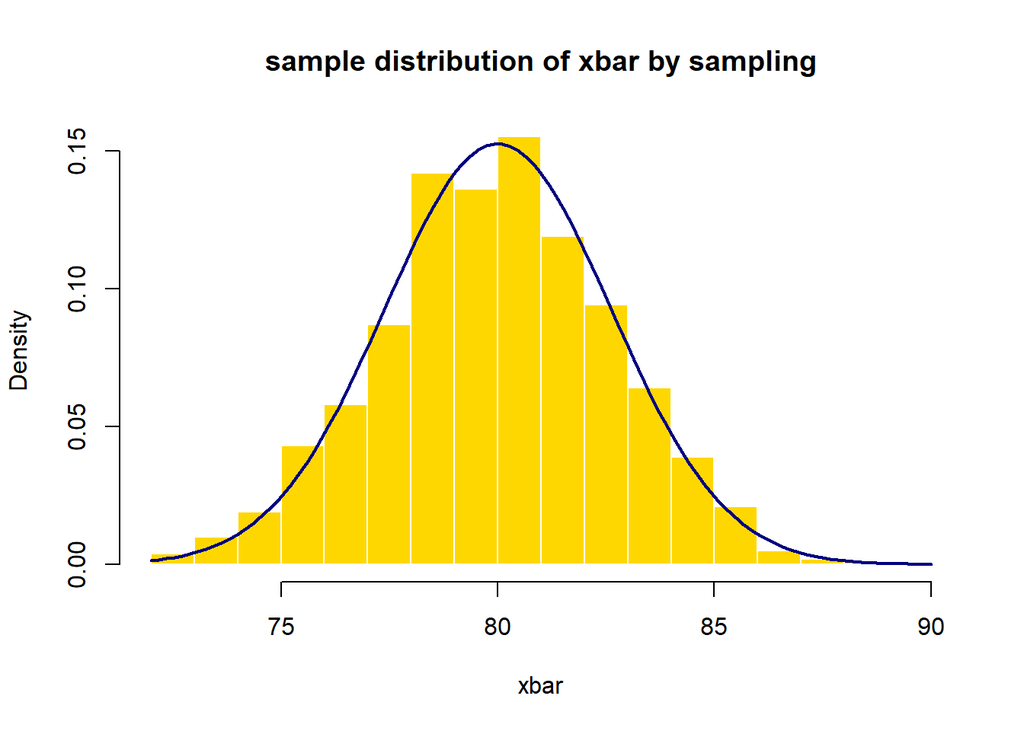

```r
#draw sample distribution
hist(simu.xbar,probability = T,breaks = 20,main="sample distribution of xbar by sampling",xlab="xbar",col = "gold",border="white")
#加上理論的部分
curve(dnorm(x,80,2.61712),add=T,col="navy",lwd=2)
```

**mean of xbar is 80,sd is2.61712**

### c

```r
mean=80*365;mean
```

```
## [1] 29200
```

```r
sd=sqrt(365)*50;sd
```

```
## [1] 955.2487
```

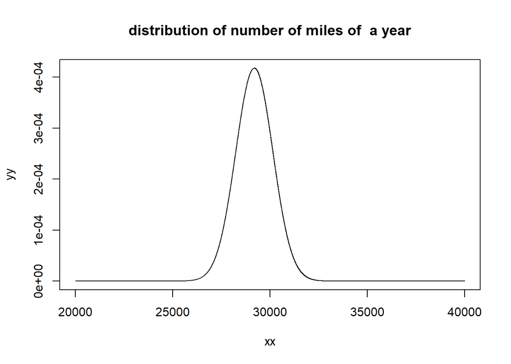

```r
xx = seq(20000, 40000, length.out =20001)
yy = dnorm(xx, mean, sd)
plot(x = xx, y = yy, type = "l", main = "distribution of number of miles of  a year")
```

**apporximate distribution is:mean=29200,sd=955.2487**

### d

b小題的曲線是常態分佈是可能的，因為他是xbar的分布圖，只要符合隨機抽樣的數量夠多(>30)或是成常態分布，他的xbar就會成常態分布

## 9.74

### a

mu_d which means the mean of the differense of each pair of population,which belongs to SD Module 4:paired difference

### b

dbar which means the mean of the differense of each sample pair

### c

yes it would change because new condition is independent but original condition is dependent  
it would change to mu1-mu2 and s1-s2

### d

```r
mean=10;mean
```

```
## [1] 10
```

```r
sd=5/sqrt(50);sd
```

```
## [1] 0.7071068
```

```r
mean+3*sd
```

```
## [1] 12.12132
```

```r
mean-3*sd
```

```
## [1] 7.87868
```

**the sampling distribution of xbar :mean=10,sd=0.7071068**

### e

```r
#sample one time
#每次有n個觀測者
norm.x=function(n,mu,sigma){
  samp=rnorm(n,mu,sigma)
  xbar=mean(samp)
  return(xbar)
}
#sample multiple times
simu.xbar=c()
for (j in 1:1000){
  x=norm.x(50,10,5)
  simu.xbar[j]=x
}
```

```r
#計算模擬的xbar的mean和sd
simu.mean=mean(simu.xbar)
simu.sd=sd(simu.xbar)
#計算理論的xbar的mean和sd
mu=10
sigma=5
n=50
theo.mean=mu
theo.sd=sigma/sqrt(n)
```

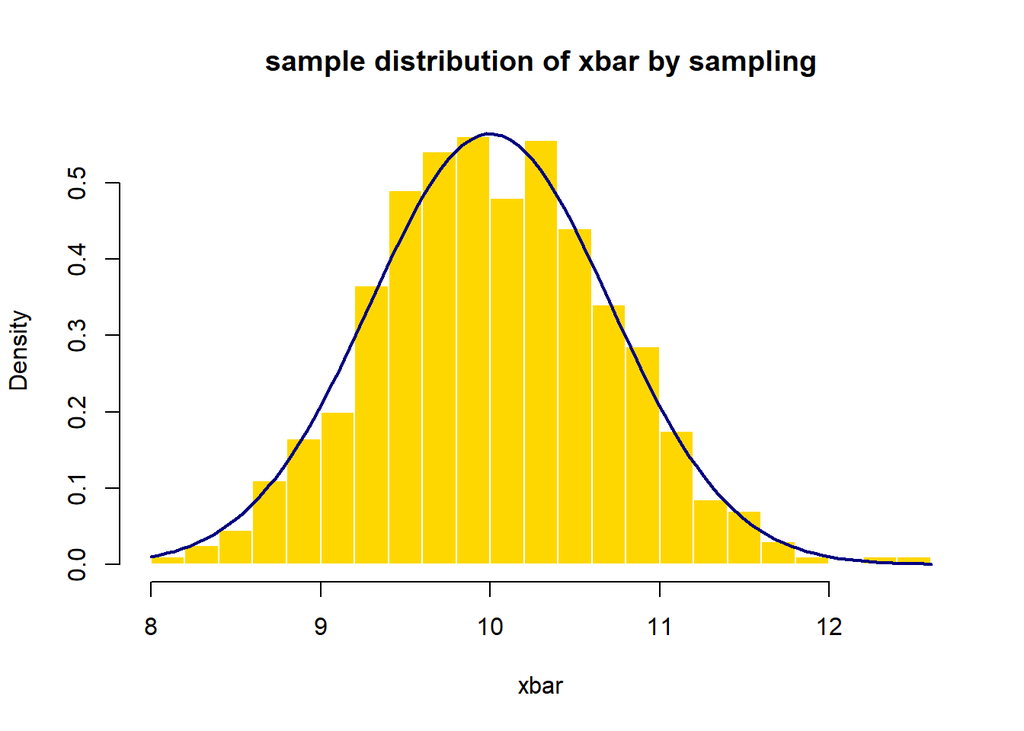

```r
#draw sample distribution
hist(simu.xbar,probability = T,breaks = 20,main="sample distribution of xbar by sampling",xlab="xbar",col = "gold",border="white")
#加上理論的部分
curve(dnorm(x,theo.mean,theo.sd),add=T,col="navy",lwd=2)
```

### f

I would be surprised if store band has higher mean number of unpopped kernels;  
because according to theory of normal curve, 99.7% of xbar should between mean-3sd=7.87 and mean+3sd=12.1,  
which means store band should have less unpopped kernel between 7 and 12.  
It is less likely that store band has more unpopped kernels

## 9.80

### a,b

```r
mu1=4.5
sigma1=1.5
mu2=8
sigma2=2
mean=mu2-mu1;mean
```

```
## [1] 3.5
```

```r
sd=sqrt((sigma2^2/23)+(sigma1^2/25));sd
```

```
## [1] 0.5137247
```

**the sampling distribution of xbar2-xbar1 :mean=3.5,sd=0.5137247**

### c

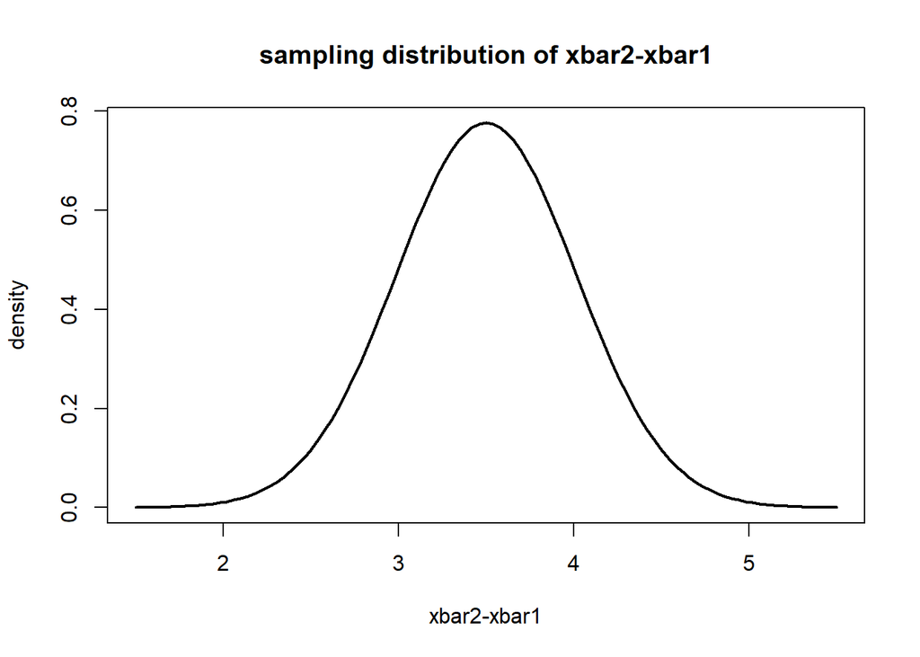

```r
curve(dnorm(x,mean,sd),lwd=2,main="sampling distribution of xbar2-xbar1",xlim=c(1.5,5.5),xlab="xbar2-xbar1",ylab="density")
```

### d

```r
#z-score
z=(3.6-3.5)/0.5137247
z
```

```
## [1] 0.1946568
```

**z=0.19代表距離平均數0.19個表準差,so it is reasonable(只要小於3個標準差就有可能發生)**

### e

```r
#z-score
z=(0-3.5)/0.5137247
z
```

```
## [1] -6.812988
```

**z=-6.81代表距離平均數6.81個表準差,so it is not reasonable(需要小於3個標準差才可能發生)**

## 9.106

### a

```r
mu=100
sigma=15
sd=15/sqrt(36)
z1=(97-mu)/sd;z1
```

```
## [1] -1.2
```

**standardized for xbar 97 is -1.2**

### b

```r
z2=(105-mu)/sd;z2
```

```
## [1] 2
```

**standardized for 105 is 2**

### c

```r
mean=mu;mean
```

```
## [1] 100
```

```r
sd=sigma/sqrt(36);sd
```

```
## [1] 2.5
```

**sampling distribution of xbar is mean=100,sd=2.5**

### d

```r
#sample one time
#每次有n個觀測者
norm.x=function(n,mu,sigma){
  samp=rnorm(n,mu,sigma)
  xbar=mean(samp)
  return(xbar)
}
#sample multiple times
simu.xbar=c()
for (j in 1:1000){
  x=norm.x(36,100,15)
  simu.xbar[j]=x
}
```

```r
#計算模擬的xbar的mean和sd
simu.mean=mean(simu.xbar)
simu.sd=sd(simu.xbar)
#計算理論的xbar的mean和sd
mu=100
sigma=15
n=36
theo.mean=mu
theo.sd=sigma/sqrt(n)
```

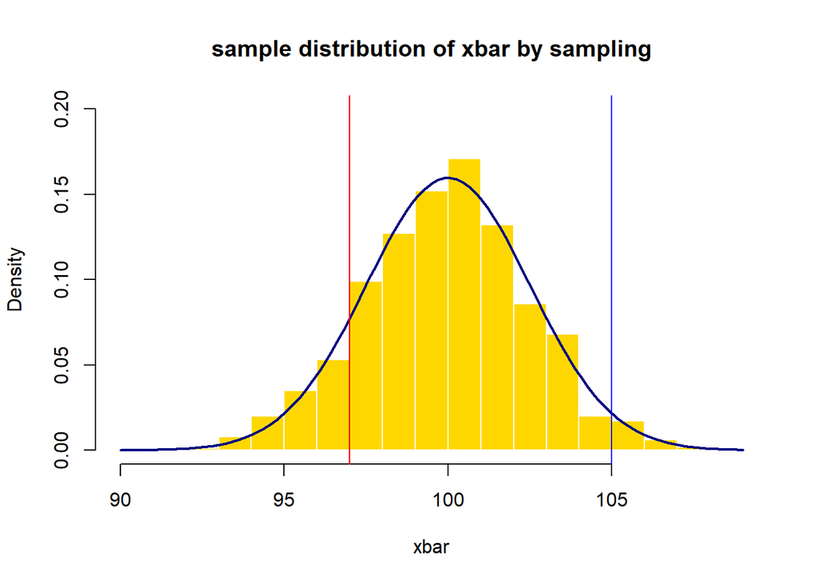

```r
#draw sample distribution
hist(simu.xbar,probability = T,breaks = 20,main="sample distribution of xbar by sampling",xlab="xbar",col = "gold",border="white",ylim=c(0,0.2))
#加上理論的部分
curve(dnorm(x,theo.mean,theo.sd),add=T,col="navy",lwd=2)
abline(v = 97, col = "red")
abline(v = 105, col = "blue")
```

### e

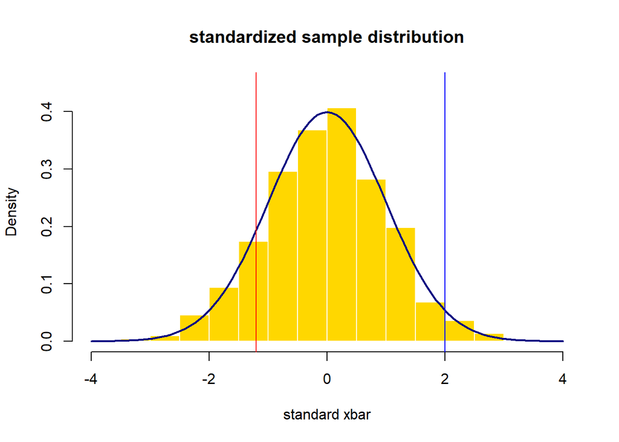

```r
#z-score
simu.z=(simu.xbar-theo.mean)/theo.sd
#distribution of z-score
hist(simu.z,probability = T,breaks = 20,main="standardized sample distribution",xlab="standard xbar",col = "gold",border="white",ylim=c(0,0.45))
curve(dnorm(x,0,1),add=T,col="navy",lwd=2)
abline(v = z1, col = "red")
abline(v = z2, col = "blue")
```

### f

兩張圖的差別在d小題是用模擬的，模擬每次抽驗36人抽1000次平均數的分布  
而e小題是用理論值來看，將sample的平均數標準化後看跟平均數差幾個標準差(曲線部分)，  
理論上來說兩者的分布應該非常相近，只是e小題是將d小題標準化後的樣子

## r studio

### example9.4

```r
#sampling one time(function is for making one mean)
#機率為p的時候抽n個，回傳成功的機率
bino.x=function(n,p){
  pp=p*10
  samp=sample(1:10,n,replace=T)#隨機抽n個
  response=c()
  #確認哪些符合條件
  for (i in 1:length(samp)){
    if (samp[i]<=pp){
      response[i]=1
    }else{
      response[i]=0
    }
  }
  return(sum(response)/n)#回傳符合的比例
}

#sampling multiple times
#return 400 phat
simu.phat=c()
for (j in 1:400){
  x=bino.x(2400,0.4)
  simu.phat[j]=x
}
```

```r
#計算模擬的phat的mean和sd
simu.mean=mean(simu.phat)
simu.sd=sd(simu.phat)
#計算理論的phat的mean和sd
n=2400
p=0.4
theo.mean=p
theo.sd=sqrt(p*(1-p)/n)
```

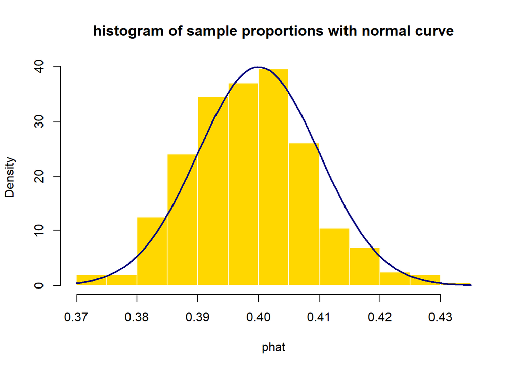

```r
#draw sample distribution
hist(simu.phat ,breaks = 20, prob = T ,main="histogram of sample proportions with normal curve",xlab="phat",col = "gold",border="white")
#加上理論的部分
curve(dnorm(x,theo.mean,theo.sd),add=T,col="navy",lwd=2)
```

**根據疊圖可看出兩個曲線相差不大，模擬和理論值差不多**

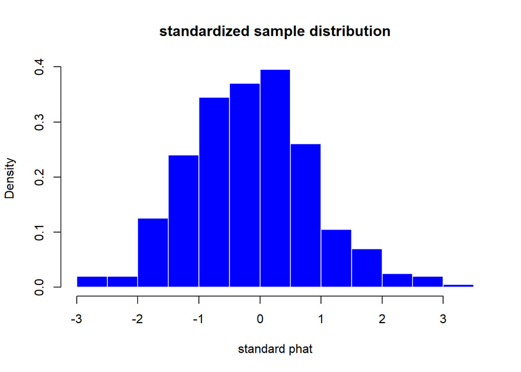

```r
#z-score
simu.z=(simu.phat-theo.mean)/theo.sd
#distribution of z-score
hist(simu.z,probability = T,breaks = 20,main="standardized sample distribution",xlab="standard phat",col="blue",border = "white")
```

### example9.6

```r
#sampling one time(function is for making one mean)
#機率為p的時候抽n個，回傳成功的機率
bino.x=function(n,p){
  pp=p*100
  samp=sample(1:100,n,replace=T)#隨機抽n個
  response=c()
  #確認哪些符合條件
  for (i in 1:length(samp)){
    if (samp[i]<=pp){
      response[i]=1
    }else{
      response[i]=0
    }
  }
  return(sum(response)/n)#回傳符合的比例
}

#sampling multiple times
#return 400 phat
simu.phat=c()
for (j in 1:1000){
  x=bino.x(1017,0.37)-bino.x(885,0.27)
  simu.phat[j]=x
}
```

```r
#計算模擬的phat的mean和sd
simu.mean=mean(simu.phat)
simu.sd=sd(simu.phat)
#計算理論的phat的mean和sd
theo.mean=0.37-0.27
theo.sd=sqrt(0.37*(1-0.37)/1017+0.27*(1-0.27)/885)
```

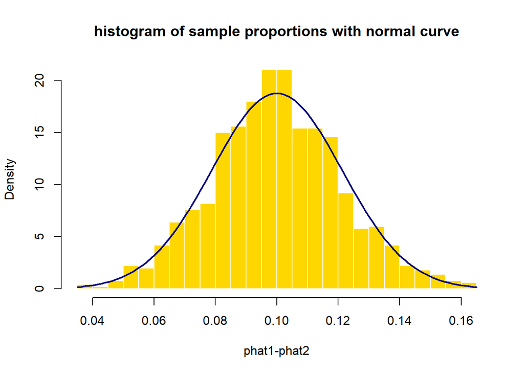

```r
#draw sample distribution
hist(simu.phat,probability = T,breaks = 20,main="histogram of sample proportions with normal curve",xlab="phat1-phat2",col = "gold",border="white")
#加上理論的部分
curve(dnorm(x,theo.mean,theo.sd),add=T,col="navy",lwd=2)
```

**根據疊圖可看出兩個曲線相差不大，模擬和理論值差不多**

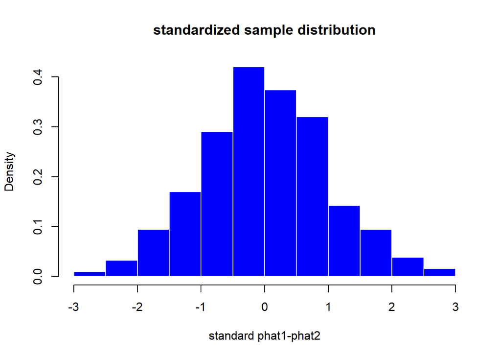

```r
#z-score
simu.z=(simu.phat-theo.mean)/theo.sd
#distribution of z-score
hist(simu.z,probability = T,breaks = 20,main="standardized sample distribution",xlab="standard phat1-phat2",col="blue",border = "white")
```

### example9.8

```r
#sample one time
#每次有n個觀測者
norm.x=function(n,mu,sigma){
  samp=rnorm(n,mu,sigma)
  xbar=mean(samp)
  return(xbar)
}
#sample multiple times
simu.xbar=c()
for (j in 1:400){
  x=norm.x(25,8,5)
  simu.xbar[j]=x
}
```

```r
#計算模擬的xbar的mean和sd
simu.mean=mean(simu.xbar)
simu.sd=sd(simu.xbar)
#計算理論的xbar的mean和sd
mu=8
sigma=5
n=25
theo.mean=mu
theo.sd=sigma/sqrt(n)
```

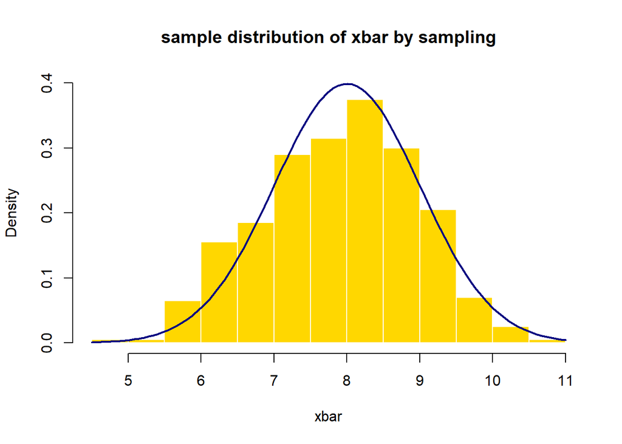

```r
#draw sample distribution
hist(simu.xbar,probability = T,breaks = 20,main="sample distribution of xbar by sampling",xlab="xbar",col = "gold",border="white",ylim=c(0,0.4))
#加上理論的部分
curve(dnorm(x,theo.mean,theo.sd),add=T,col="navy",lwd=2)
```

**根據疊圖可看出兩個曲線相差不大，模擬和理論值差不多**

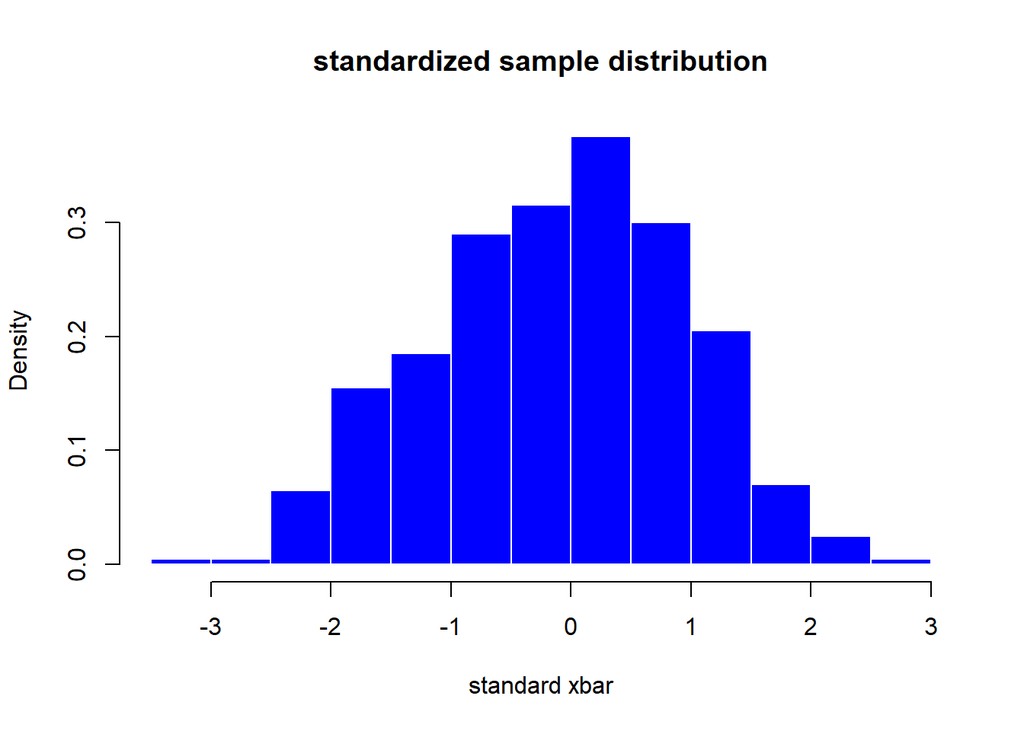

```r
#z-score
simu.z=(simu.xbar-theo.mean)/theo.sd
#distribution of z-score
hist(simu.z,probability = T,breaks = 20,main="standardized sample distribution",xlab="standard xbar",col="blue",border = "white")
```

### example9.9

```r
#sample one time
#每次有n個觀測者
norm.x=function(n,mu,sigma){
  samp=rnorm(n,mu,sigma)
  xbar=mean(samp)
  return(xbar)
}
#sample multiple times
simu.xbar=c()
for (j in 1:1000){
  x=norm.x(60,0,7)
  simu.xbar[j]=x
}
```

```r
#計算模擬的xbar的mean和sd
simu.mean=mean(simu.xbar)
simu.sd=sd(simu.xbar)
#計算理論的xbar的mean和sd
mu=0
sigma=7
n=60
theo.mean=mu
theo.sd=sigma/sqrt(n)
```

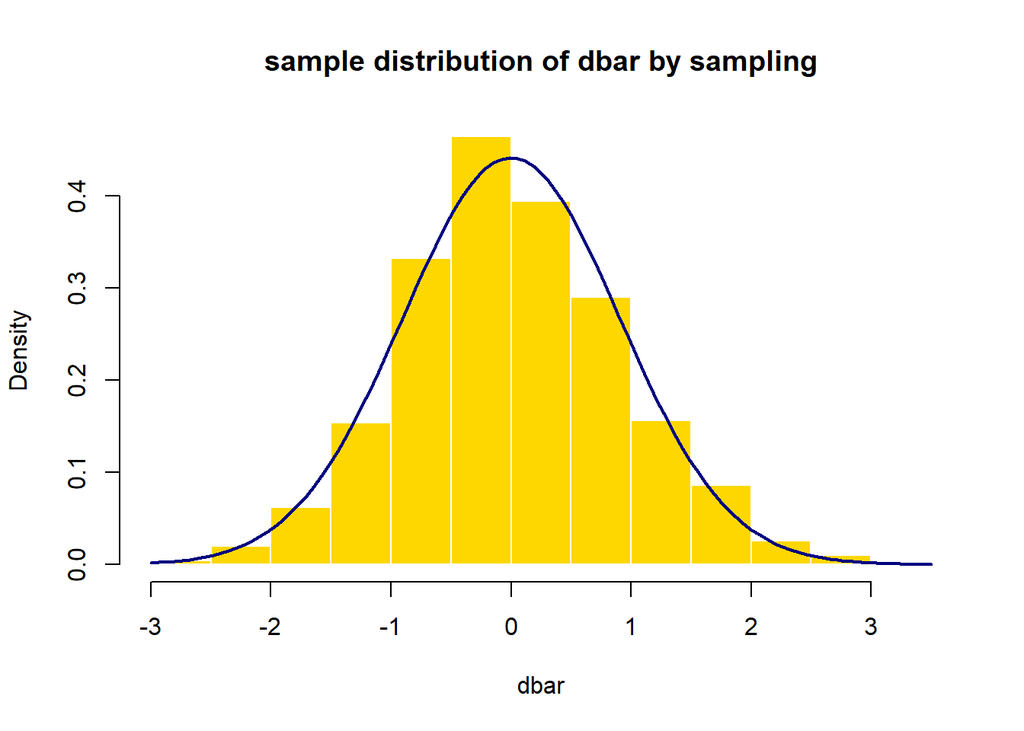

```r
#draw sample distribution
hist(simu.xbar,probability = T,breaks = 20,main="sample distribution of dbar by sampling",xlab="dbar",col = "gold",border="white")
#加上理論的部分
curve(dnorm(x,theo.mean,theo.sd),add=T,col="navy",lwd=2)
```

**根據疊圖可看出兩個曲線相差不大，模擬和理論值差不多**

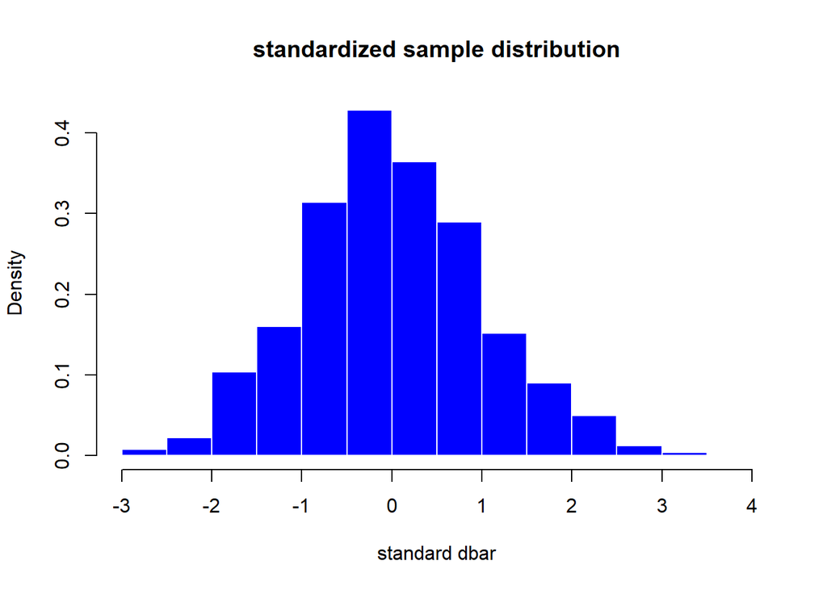

```r
#z-score
simu.z=(simu.xbar-theo.mean)/theo.sd
#distribution of z-score
hist(simu.z,probability = T,breaks = 20,main="standardized sample distribution",xlab="standard dbar",col="blue",border = "white")
```

### example9.10

此題沒有提供母體的平均數和標準差，因此此計算是以樣本的平均數和標準差來計算

```r
#sample one time
#每次有n個觀測者
norm.x=function(n,mu,sigma){
  samp=rnorm(n,mu,sigma)
  xbar=mean(samp)
  return(xbar)
}
#sample multiple times
simu.xbar=c()
for (j in 1:1000){
  x=norm.x(87,107,17)-norm.x(102,88,15)
  simu.xbar[j]=x
}
```

```r
#計算模擬的xbar的mean和sd
simu.mean=mean(simu.xbar);simu.mean
```

```
## [1] 19.01359
```

```r
simu.sd=sd(simu.xbar);simu.sd
```

```
## [1] 2.396904
```

```r
#計算理論的xbar的mean和sd
theo.mean=0;theo.mean
```

```
## [1] 0
```

```r
theo.sd=sqrt(15^2/87+15^2/102);theo.sd
```

```
## [1] 2.189084
```

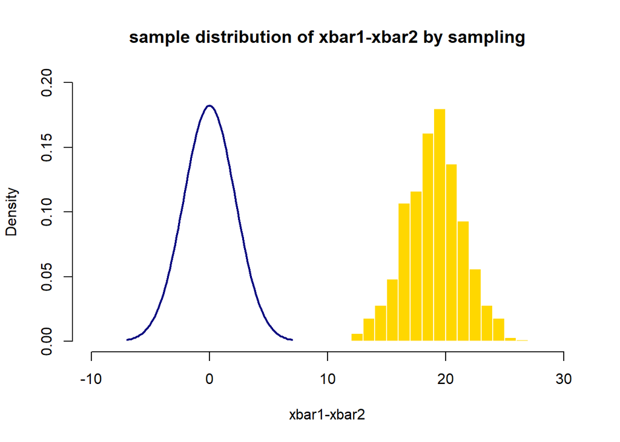

```r
#draw sample distribution
hist(simu.xbar,probability = T,breaks = 20,main="sample distribution of xbar1-xbar2 by sampling",xlab="xbar1-xbar2",col = "gold",border="white",xlim=c(-10,30),ylim=c(0,0.2))
#加上理論的部分
curve(dnorm(x,theo.mean,theo.sd),add=T,col="navy",lwd=2,xlim=c(-7,7))
```

**根據疊圖可看出兩個曲線相差很大，已知真實的差距是0，根據曲線可推估此次的sample 是outlier**

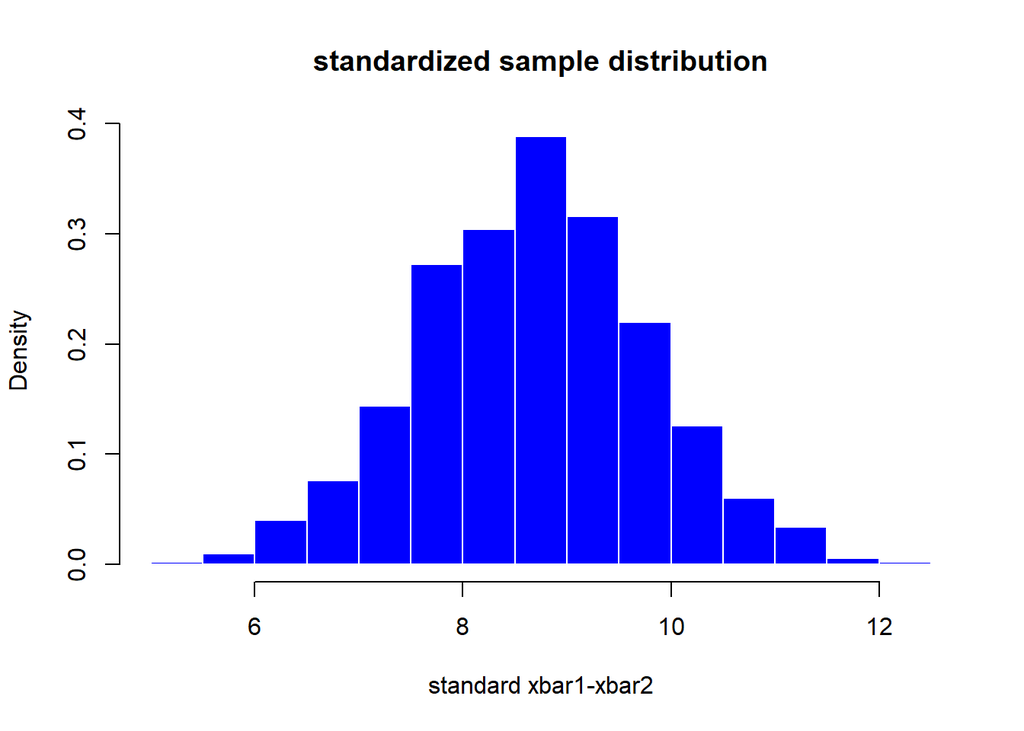

```r
#z-score
simu.z=(simu.xbar-theo.mean)/theo.sd
#distribution of z-score
hist(simu.z,probability = T,breaks = 20,main="standardized sample distribution",xlab="standard xbar1-xbar2",col="blue",border = "white")
```